After a few weeks of hiatus from #TidyTuesday, I am back with 27-July’21 dataset which is about Olympics. In this exercise, I will try to develop a model to predict medalists using a bagged tree model. This post is intended to workflow through a bare-bones model. So, we are not really focused on the results.

## Libraries

```r
library(tidyverse)
library(tidymodels)
library(skimr)

library(tidytuesdayR)

library(parallel)
library(doParallel)
library(tictoc)

tidymodels_prefer()
conflicted::conflict_prefer("vi", "vip")
```

## >>>Set parallel processing

```r
# Enable parallel processing

cores<-detectCores(logical=F)-1
# cores

core_cluster<-makePSOCKcluster(cores)
# core_cluster

registerDoParallel(core_cluster)
```

## Get Data

```r
tt_data<-tt_load("2021-07-27")
olympics<-tt_data$olympics
regions<-tt_data$regions
```

## Some exploration

```r
olympics%>%
  skim()
```

Data summary

| Name | Piped data |
| --- | --- |
| Number of rows | 271116 |
| Number of columns | 15 |
| _______________________ |  |
| Column type frequency: |  |
| character | 10 |
| numeric | 5 |
| ________________________ |  |
| Group variables | None |

**Variable type: character**

| skim_variable | n_missing | complete_rate | min | max | empty | n_unique | whitespace |
| --- | --- | --- | --- | --- | --- | --- | --- |
| name | 0 | 1.00 | 2 | 108 | 0 | 134731 | 0 |
| sex | 0 | 1.00 | 1 | 1 | 0 | 2 | 0 |
| team | 0 | 1.00 | 2 | 47 | 0 | 1184 | 0 |
| noc | 0 | 1.00 | 3 | 3 | 0 | 230 | 0 |
| games | 0 | 1.00 | 11 | 11 | 0 | 51 | 0 |
| season | 0 | 1.00 | 6 | 6 | 0 | 2 | 0 |
| city | 0 | 1.00 | 4 | 22 | 0 | 42 | 0 |
| sport | 0 | 1.00 | 4 | 25 | 0 | 66 | 0 |
| event | 0 | 1.00 | 15 | 85 | 0 | 765 | 0 |
| medal | 231333 | 0.15 | 4 | 6 | 0 | 3 | 0 |

**Variable type: numeric**

| skim_variable | n_missing | complete_rate | mean | sd | p0 | p25 | p50 | p75 | p100 | hist |
| --- | --- | --- | --- | --- | --- | --- | --- | --- | --- | --- |
| id | 0 | 1.00 | 68248.95 | 39022.29 | 1 | 34643 | 68205 | 102097.2 | 135571 | ▇▇▇▇▇ |
| age | 9474 | 0.97 | 25.56 | 6.39 | 10 | 21 | 24 | 28.0 | 97 | ▇▃▁▁▁ |
| height | 60171 | 0.78 | 175.34 | 10.52 | 127 | 168 | 175 | 183.0 | 226 | ▁▂▇▂▁ |
| weight | 62875 | 0.77 | 70.70 | 14.35 | 25 | 60 | 70 | 79.0 | 214 | ▃▇▁▁▁ |
| year | 0 | 1.00 | 1978.38 | 29.88 | 1896 | 1960 | 1988 | 2002.0 | 2016 | ▁▂▃▆▇ |

On medal field, we see 14.7% got medals. Age, height and weight has some data missing.

## Cleaned Dataframe

We are going to do binary classification with target is to predict whether someone is a medalist or not.

```r
olympics_clean<-olympics%>%
  mutate(
    medalist=factor(if_else(is.na(medal),"N","Y")),
    medalist=fct_relevel(medalist,"Y")
  )%>%
  select(-c(medal,id,name,team,games,event,city))


olympics_clean%>%
  glimpse()
```

```
## Rows: 271,116
## Columns: 9
## $ sex      <chr> "M", "M", "M", "M", "F", "F", "F", "F", "F", "F", "M", "M", "~
## $ age      <dbl> 24, 23, 24, 34, 21, 21, 25, 25, 27, 27, 31, 31, 31, 31, 33, 3~
## $ height   <dbl> 180, 170, NA, NA, 185, 185, 185, 185, 185, 185, 188, 188, 188~
## $ weight   <dbl> 80, 60, NA, NA, 82, 82, 82, 82, 82, 82, 75, 75, 75, 75, 75, 7~
## $ noc      <chr> "CHN", "CHN", "DEN", "DEN", "NED", "NED", "NED", "NED", "NED"~
## $ year     <dbl> 1992, 2012, 1920, 1900, 1988, 1988, 1992, 1992, 1994, 1994, 1~
## $ season   <chr> "Summer", "Summer", "Summer", "Summer", "Winter", "Winter", "~
## $ sport    <chr> "Basketball", "Judo", "Football", "Tug-Of-War", "Speed Skatin~
## $ medalist <fct> N, N, N, Y, N, N, N, N, N, N, N, N, N, N, N, N, N, N, N, N, N~
```

## Partition

Then I split the data to train and test set. For further cross-validation, I split the train set in 5 stratified folds.

```r
set.seed(123)
split<-initial_split(olympics_clean,strata = medalist)

train<-training(split)
test<-testing(split)

set.seed(123)
folds<-vfold_cv(train,v=5,strata = medalist)
```

## Recipe

At pre-processing, we are only going to do imputation for missing values in age, height and weight columns with bag tree model using sex, noc and sport as predictors.

```r
rec_base<-train%>%
  recipe(medalist~.)%>%
  step_novel(all_nominal_predictors())%>%
  step_unknown(all_nominal_predictors())%>%
  step_impute_bag(age,height,
                  weight,
                  impute_with = imp_vars(sex,noc,sport))


baked<-rec_base%>%
  prep()%>%
  bake(new_data=NULL)


baked%>%
  skim()
```

Data summary

| Name | Piped data |
| --- | --- |
| Number of rows | 203336 |
| Number of columns | 9 |
| _______________________ |  |
| Column type frequency: |  |
| factor | 5 |
| numeric | 4 |
| ________________________ |  |
| Group variables | None |

**Variable type: factor**

| skim_variable | n_missing | complete_rate | ordered | n_unique | top_counts |
| --- | --- | --- | --- | --- | --- |
| sex | 0 | 1 | FALSE | 2 | M: 147575, F: 55761, new: 0, unk: 0 |
| noc | 0 | 1 | FALSE | 229 | USA: 14169, FRA: 9539, GBR: 9158, ITA: 7960 |
| season | 0 | 1 | FALSE | 2 | Sum: 167111, Win: 36225, new: 0, unk: 0 |
| sport | 0 | 1 | FALSE | 65 | Ath: 29120, Gym: 19982, Swi: 17364, Sho: 8636 |
| medalist | 0 | 1 | FALSE | 2 | N: 173499, Y: 29837 |

**Variable type: numeric**

| skim_variable | n_missing | complete_rate | mean | sd | p0 | p25 | p50 | p75 | p100 | hist |
| --- | --- | --- | --- | --- | --- | --- | --- | --- | --- | --- |
| age | 0 | 1 | 25.62 | 6.36 | 10 | 22 | 25 | 28.00 | 97 | ▇▃▁▁▁ |
| height | 0 | 1 | 175.60 | 9.82 | 127 | 170 | 176 | 182.00 | 226 | ▁▂▇▁▁ |
| weight | 0 | 1 | 71.24 | 13.28 | 25 | 62 | 71 | 78.94 | 198 | ▂▇▁▁▁ |
| year | 0 | 1 | 1978.38 | 29.88 | 1896 | 1960 | 1988 | 2002.00 | 2016 | ▁▂▃▆▇ |

After imputation, you can see that no missing data in our train set.

## Model

Next I will be using a bagged tree model for training with tree depth, minimum number of data points in node and cost complexity as tuning parameters.

```r
bag_tree_rpart_spec <-
  baguette::bag_tree(min_n=tune(),
                     tree_depth = tune(),
                     cost_complexity = tune()
                     ) %>%
  set_engine('rpart') %>%
  set_mode('classification')
```

## Workflow

Next, I construct the workflow.

```r
bagT_wf<-workflow()%>%
  add_recipe(rec_base)%>%
  add_model(bag_tree_rpart_spec)
```

## Tune Grid

For hyper-parameter tuning we define 10 different combinations based on max entropy.

```r
set.seed(123)

grid_bagT<-grid_max_entropy(
  bagT_wf%>%
    parameters(),
  size=10)

grid_bagT
```

```
## # A tibble: 10 x 3
##    cost_complexity tree_depth min_n
##              <dbl>      <int> <int>
##  1        6.95e- 5         12     5
##  2        8.27e- 3          4     7
##  3        2.40e- 9          8    36
##  4        1.89e- 8          3     3
##  5        7.52e- 5          9    27
##  6        4.29e- 2         13    21
##  7        1.90e- 2          3    33
##  8        5.45e- 6          3    19
##  9        2.49e- 8         13    24
## 10        1.59e-10          1    20
```

## Training time

```r
tic()

set.seed(123)
tune_bagT<-bagT_wf%>%
  tune_grid(
    resamples=folds,
    grid=grid_bagT,
    control=control_grid(parallel_over = NULL)
    )

toc()
```

## Tune results

```r
tune_bagT%>%
  show_best("roc_auc")
```

```
## # A tibble: 5 x 9
##   cost_complexity tree_depth min_n .metric .estimator  mean     n  std_err
##             <dbl>      <int> <int> <chr>   <chr>      <dbl> <int>    <dbl>
## 1   0.0000000249          13    24 roc_auc binary     0.856     5 0.000830
## 2   0.0000695             12     5 roc_auc binary     0.842     5 0.00156
## 3   0.0000752              9    27 roc_auc binary     0.801     5 0.00153
## 4   0.00000000240          8    36 roc_auc binary     0.794     5 0.00100
## 5   0.00000545             3    19 roc_auc binary     0.625     5 0.0101
## # ... with 1 more variable: .config <chr>
```

The best model roc_auc is 0.856.

## Finalize workflow with best parameters

```r
# Best parameters

best_params<-tune_bagT%>%
  select_best(metric="roc_auc")

# Create final workflow and train on whole training set
final_wf<-bagT_wf%>%
  finalize_workflow(best_params)%>%
  fit(train)
```

## Predict on validation set

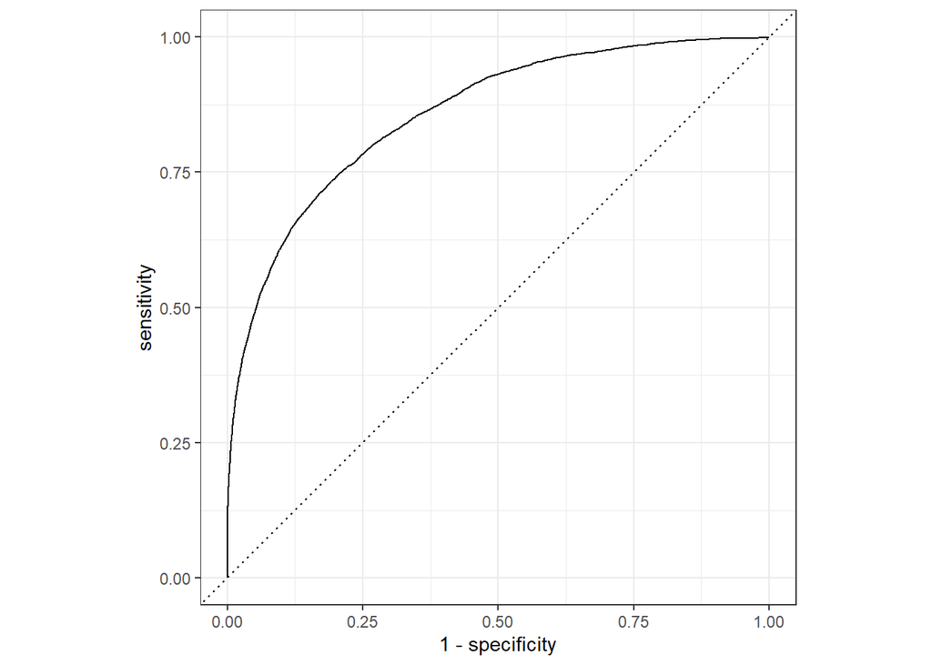

```r
test_preds<-final_wf%>%
  augment(test)


roc_curve<-test_preds%>%
  roc_curve(truth=medalist,.pred_Y)%>%
  autoplot()

roc_curve
```

```r
test_preds%>%
  roc_auc(truth=medalist,.pred_Y)
```

```
## # A tibble: 1 x 3
##   .metric .estimator .estimate
##   <chr>   <chr>          <dbl>
## 1 roc_auc binary         0.858
```

```r
test_preds%>%
  conf_mat(truth=medalist,.pred_class)%>%
  summary()
```

```
## # A tibble: 13 x 3
##    .metric              .estimator .estimate
##    <chr>                <chr>          <dbl>
##  1 accuracy             binary        0.887
##  2 kap                  binary        0.394
##  3 sens                 binary        0.305
##  4 spec                 binary        0.987
##  5 ppv                  binary        0.806
##  6 npv                  binary        0.892
##  7 mcc                  binary        0.452
##  8 j_index              binary        0.292
##  9 bal_accuracy         binary        0.646
## 10 detection_prevalence binary        0.0555
## 11 precision            binary        0.806
## 12 recall               binary        0.305
## 13 f_meas               binary        0.442
```

We get an accuracy of 0.887 with roc_auc of 0.858.

## Variable importance

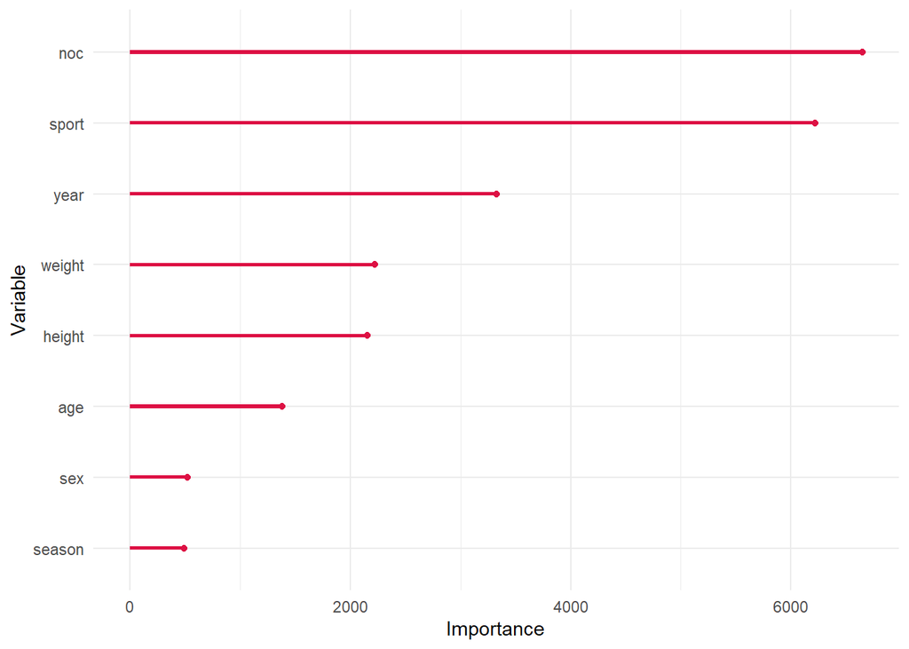

```r
vi<-final_wf%>%
  extract_fit_parsnip()

vi$fit$imp%>%
  ggplot(aes(x=reorder(term,value),y=value))+
  geom_point(color="#dd1144")+
  geom_bar(stat="identity",width=0.05,fill="#dd1144")+
  coord_flip()+
  theme_minimal()+
  labs(
    x="Variable",
    y="Importance"
  )
```

Nation and sport seems to be the most important variables.